# Aberdeen Study Group - Linear models

Deon Roos

24 October 2019

# ———————————————————————————

# Start by loading the iris data

# ———————————————————————————

We’ll be using the iris dataset.

The iris dataset is an example dataset used for teaching and is part of base R.

The data contains the terms:

- petal - the flower bit of a flower
- sepal - the green leafy bit under the petal

There are various issues with the dataset that we will see shortly, but we’ll assume it’s ok for our purposes.

```r
data(iris)  # Will appear as a "<promise>" in RStudio's environment - not a problem
```

# ———————————————————————————

# ———————————————————————————

We’ll use ggplot for doing the figures in this run through. Install the package, then load it up.

The following code installs it onto your PC (remove the # if you need to install it)

```r
# install.packages("ggplot2")
```

The following code loads the package into R. Note that R will unload all packages when you close it. You only need to install once, but will always need to reload a package.

```r
library(ggplot2)            # For creating plots
```

Also install jtools. We will use this later on - the package is for creating figures based on LM. - Think of it as the lazy way of plotting model outputs.

```r
# install.packages("jtools") # Run this code if you haven't installed the packages
library(jtools)             # For plotting model outputs
```

Always write down a comment next to where you load a package to remind yourself 6 months later why you needed *that* package

# ———————————————————————————

# STEP 0: THE MOST IMPORTANT PART!

# ———————————————————————————

Let’s create a research question.

Question (I’m not a plant person…): Does the species specific surface area of the petal predict the species specific length of the sepal?

From this we know:

- Sepal.Length is our response variable.
- We think Species influences the response variable (we could predict which species will have the longest petals).
- We think Petal.Area also influences Sepal.Length (prediction: longer sepal length = longer petal length).
- We also know that we need to create this new explanatory variable.
- We think that Petal.Area varies with Species (and vice-versa), and this interaction also influences Sepal.Length.

# ———————————————————————————

# STEP 1: CHECK YOUR DATA

# ———————————————————————————

Make sure the data is what you think it is.

E.g. Is R reading iris$Species as a factor? If not this will cause headaches later on. Check now!

```r
str(iris)
```

```
## 'data.frame':    150 obs. of  5 variables:
##  $ Sepal.Length: num  5.1 4.9 4.7 4.6 5 5.4 4.6 5 4.4 4.9 ...
##  $ Sepal.Width : num  3.5 3 3.2 3.1 3.6 3.9 3.4 3.4 2.9 3.1 ...
##  $ Petal.Length: num  1.4 1.4 1.3 1.5 1.4 1.7 1.4 1.5 1.4 1.5 ...
##  $ Petal.Width : num  0.2 0.2 0.2 0.2 0.2 0.4 0.3 0.2 0.2 0.1 ...
##  $ Species     : Factor w/ 3 levels "setosa","versicolor",..: 1 1 1 1 1 1 1 1 1 1 ...
```

There are other options for checking your data, try the following:

```r
head(iris)
```

```
##   Sepal.Length Sepal.Width Petal.Length Petal.Width Species
## 1          5.1         3.5          1.4         0.2  setosa
## 2          4.9         3.0          1.4         0.2  setosa
## 3          4.7         3.2          1.3         0.2  setosa
## 4          4.6         3.1          1.5         0.2  setosa
## 5          5.0         3.6          1.4         0.2  setosa
## 6          5.4         3.9          1.7         0.4  setosa
```

```r
summary(iris)
```

```
##   Sepal.Length    Sepal.Width     Petal.Length    Petal.Width
##  Min.   :4.300   Min.   :2.000   Min.   :1.000   Min.   :0.100
##  1st Qu.:5.100   1st Qu.:2.800   1st Qu.:1.600   1st Qu.:0.300
##  Median :5.800   Median :3.000   Median :4.350   Median :1.300
##  Mean   :5.843   Mean   :3.057   Mean   :3.758   Mean   :1.199
##  3rd Qu.:6.400   3rd Qu.:3.300   3rd Qu.:5.100   3rd Qu.:1.800
##  Max.   :7.900   Max.   :4.400   Max.   :6.900   Max.   :2.500
##        Species
##  setosa    :50
##  versicolor:50
##  virginica :50
##
##
##
```

# ———————————————————————————

# Step 1.1: Create our new explanatory variable

# ———————————————————————————

We’ll assume that we can simply do length * width to get the area of a petal.

This is obviously not correct as it assumes a petal is a rectangle, but we’ll just go with it.

Create our new vector and fill it with NA, which will be replaced with actual values.

It’s redundant here, as we could simply calculate it in the same line of code, but it’s a good habit to get into.

```r
iris$Petal.Area <- NA   # New vector filled with NA
iris$Petal.Area <- iris$Petal.Length * iris$Petal.Width
```

Check to see it if worked correctly

```r
summary(iris$Petal.Area)
```

```
##    Min. 1st Qu.  Median    Mean 3rd Qu.    Max.
##   0.110   0.420   5.615   5.794   9.690  15.870
```

# ———————————————————————————

# Step 2: Creating plots of the raw data

# ———————————————————————————

Create scatterplots to see what kind of trends there are in the data. Is it worthwhile going ahead with analysis?

Make sure that you know what’s going on with your data before you do analysis!!

- What trends do you expect before doing any analysis (can help to spot “broken” models)

You can often spot any really stupid mistakes at this point. E.g. did you measure Petal.Length in m and not cm?

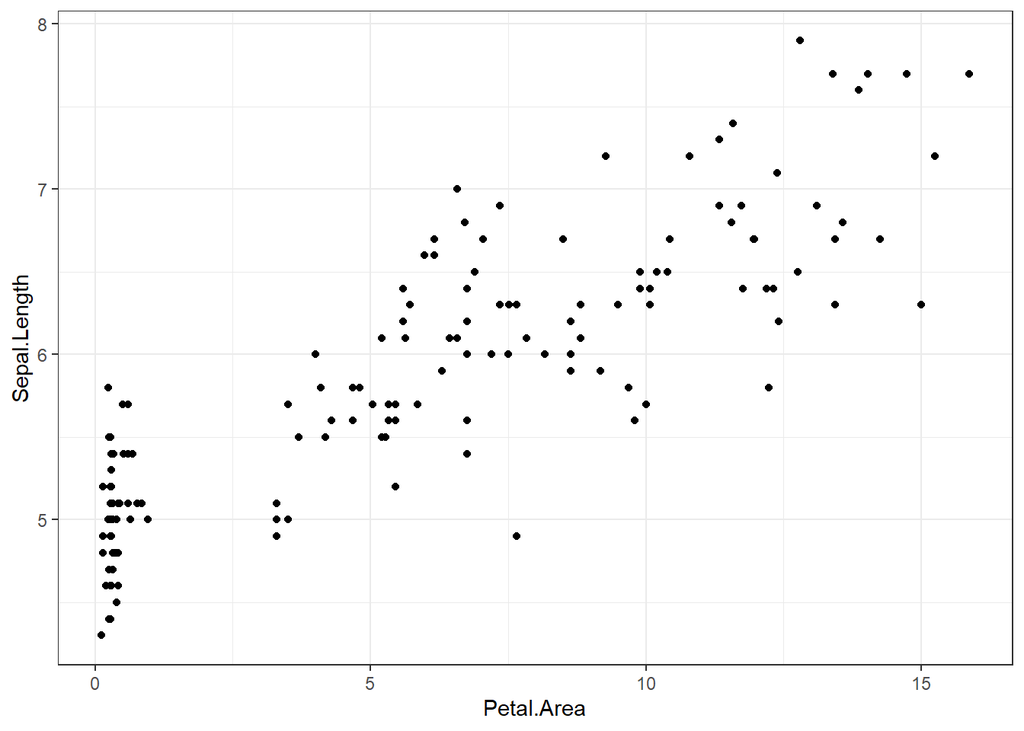

```r
ggplot(aes(x = Petal.Area, y = Sepal.Length), data = iris) + # Specify what I want in the graph using aes(), and what the dataset is
  geom_point() +                                             # Say what type of plot I want it to make (e.g. a scatterplot is geom_point)
  theme_bw()                                                 # Say which off-the-shelf theme I would like to use
```

Sepal length against species

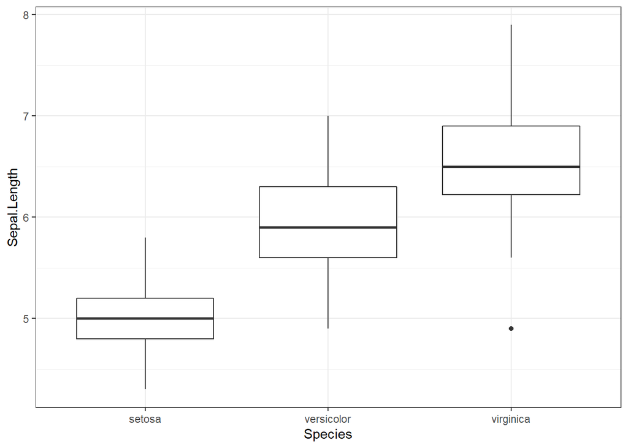

```r
ggplot(aes(x = Species, y = Sepal.Length), data = iris) +
  geom_boxplot() +
  theme_bw()
```

Doing all three together

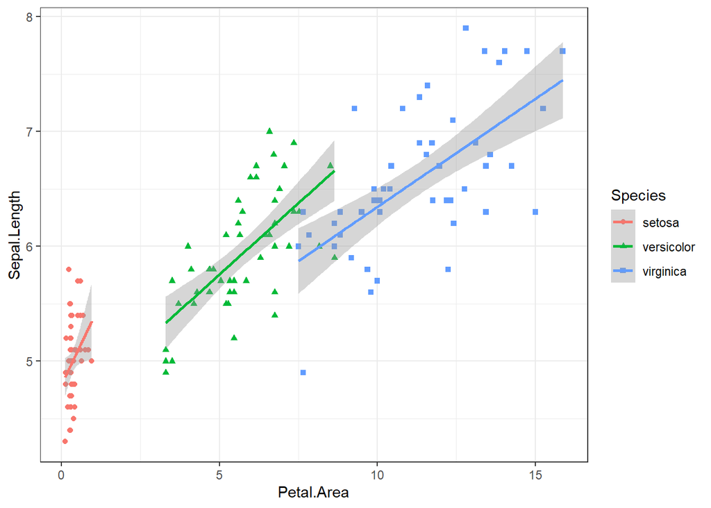

```r
ggplot(aes(x = Petal.Area, y = Sepal.Length, colour = Species, shape = Species), data = iris) +
  geom_point() +
  theme_bw() +
  geom_smooth(method = "lm")
```

Do you think there is a relationship worth exploring further with analysis?

Is the scatterplot (geom_point), using species, informative? Could we use an alternative instead?

Use histograms to check the spread of your data

Histogram of sepal length

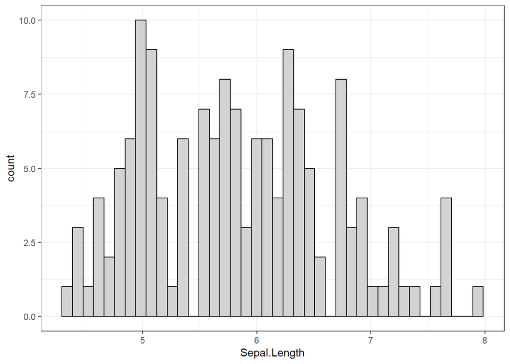

```r
ggplot() +
  geom_histogram(aes(Sepal.Length), fill = "lightgrey", colour = "black", bins = 40, data = iris) +
  theme_bw()
```

Does this histogram look ok?

Histogram of petal area

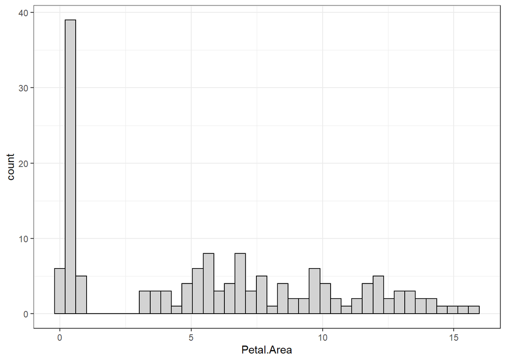

```r
ggplot() +
  geom_histogram(aes(Petal.Area), fill = "lightgrey", colour = "black", bins = 40, data = iris) +
  theme_bw()
```

Does the distribution of Petal.Area look alright? Might it be worth transforming?

Let’s check to see if we can explain the weird distribution

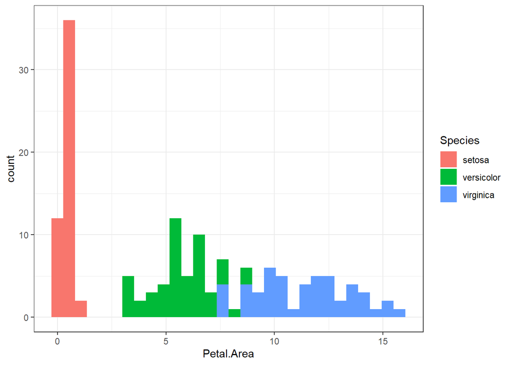

```r
ggplot() +
  geom_histogram(aes(Petal.Area, fill = Species), data = iris) +
  theme_bw()
```

It looks like the different species are causing the weird distribution

Let’s try transforming Petal.Area

As a rough rule of thumb there are 4 commonly used transformations:

- Squared: x^2
- Square root: sqrt(x)
- Natural log: log(x)
- Log of base 10: log10(x)

```r
iris$Petal.Area.Squared <- NA
iris$Petal.Area.Squared <- (iris$Petal.Area)^2
```

Check histogram to see how it looks now:

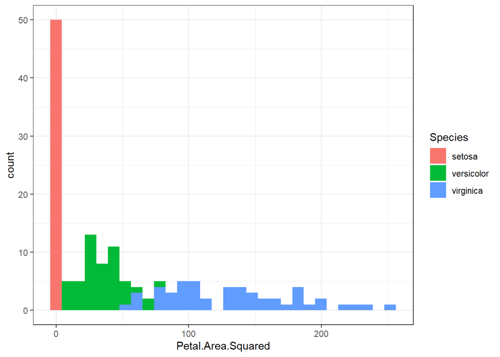

```r
ggplot() +
  geom_histogram(aes(Petal.Area.Squared, fill = Species), data = iris) +
  theme_bw()
```

Maybe looks better. We can try using the different versions of petal area later and see if it makes a difference.

To see a normal distribution, and how it can vary, try altering the rnorm(n = 150, mean = 10, sd = 3) in the following code or just run it multiple times with different seeds.

Note: if you wanted the random numbers to be consistent (despite being random) use set.seed() and add a number in the brackets.

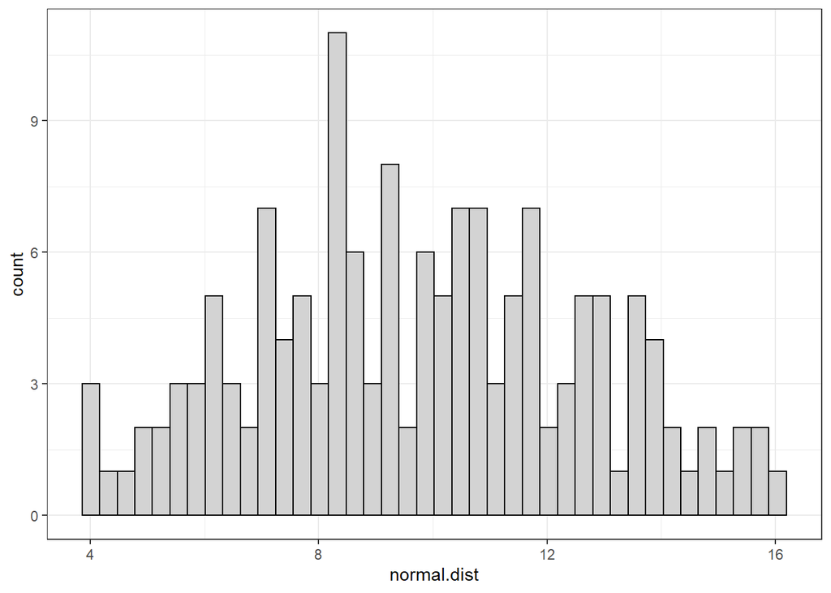

```r
set.seed(4638564)

normal.dist <- rnorm(n = 150, mean = 10, sd = 3)
ggplot() +
  geom_histogram(aes(normal.dist), fill = "lightgrey", colour = "black", bins = 40) +
  theme_bw()
```

Can you make a histogram of species? Why not?

Note that the use of transformations has some controversy around them. Some, like Zuur, argue against the use of them, as it can “hide” subtle variation in variables.

E.g. Squaring petal area has removed lots of variation in setosa (see plots below).

Use transformations when you feel it is appropriate. Personally, I try not to as a general rule. Transformations can lead to a perfectly fine model, but when backtransformed, is silly

# ———————————————————————————

# STEP 3: CHECK FOR OUTLIERS

# ———————————————————————————

Outliers can have a disprportionate effect on the model. It’s best to try and catch them early rather than later, though there are ways of detecting them downstream.

We can use boxplots to check for this

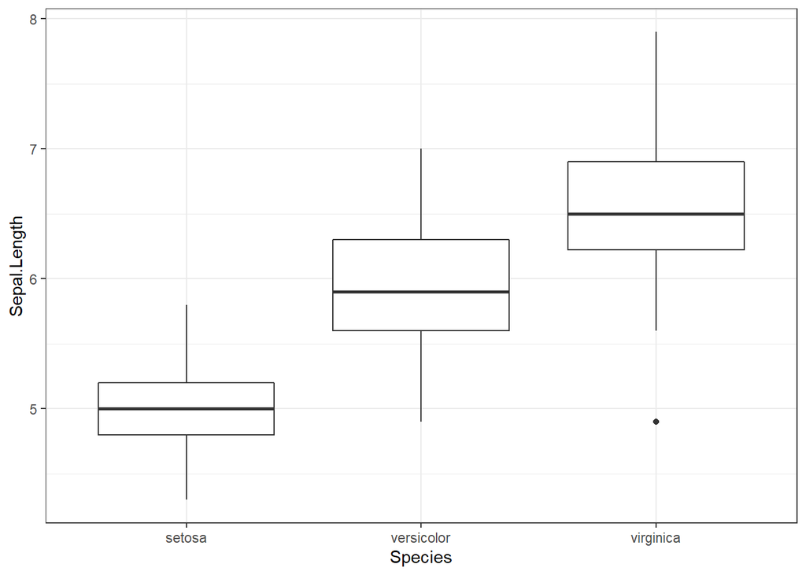

```r
ggplot(aes(x = Species, y = Sepal.Length), data = iris) +
  geom_boxplot() +
  theme_bw()
```

Before running the following code, do you think it will be helpful?

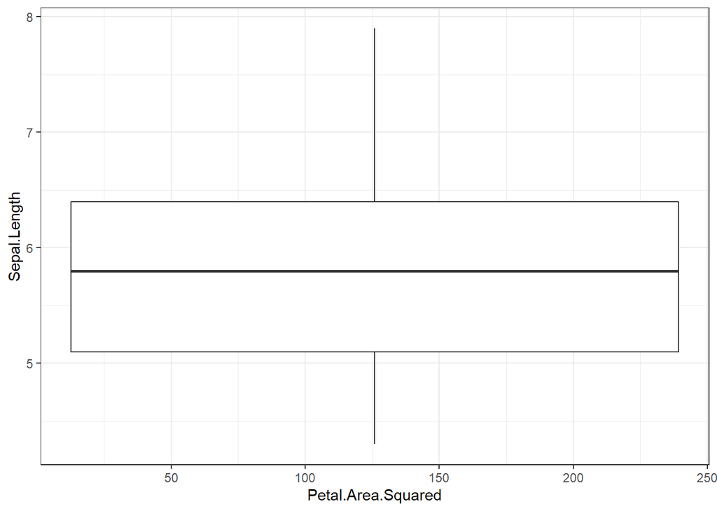

```r
ggplot(aes(x = Petal.Area.Squared, y = Sepal.Length), data = iris) +
  geom_boxplot() +
  theme_bw()
```

This may be more a more informative version of the above plot.

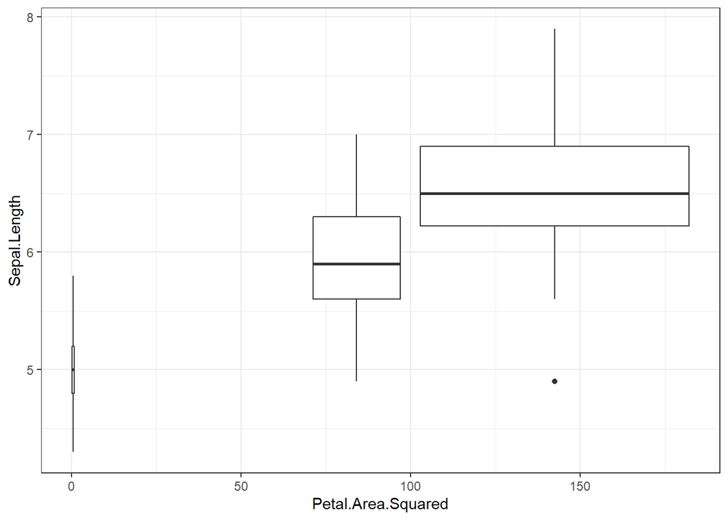

```r
ggplot(aes(x = Petal.Area.Squared, y = Sepal.Length, group = Species), data = iris) +
  geom_boxplot() +
  theme_bw()
```

Let’s try with the unsqaured petal area:

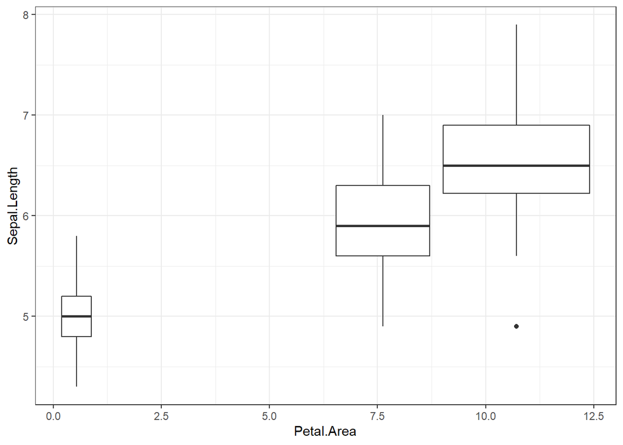

```r
ggplot(aes(x = Petal.Area, y = Sepal.Length, group = Species), data = iris) +
  geom_boxplot() +
  theme_bw()
```

Are there any outliers?

- Outliers can be data entry mistakes - in which case remove and state very clearly that you removed it because you think it was an entry mistake.
- Or they can just be bioligcally extreme values (though still biologically resonable).
- E.g. someone who is 2.2 m tall could present as an outlier, but is obviously still biologically reasonable (they exist after all…).
- Whatever you do with outliers is fine so long as you can justify it, just be completely transparent.

Why are outliers a problem?

https://observablehq.com/@tmcw/bring-your-own-doodles-linear-regression

We will check this later on after running a model.

# ———————————————————————————

# STEP 4: Check for collinearity in your data

# ———————————————————————————

Collineairty, or correlation, in explanatory variables is dangerous when it comes to modelling.

Let’s assume species and Petal.Width are correlated with each other. If we include both in a model, and they both have an effect, how will we know if it isn’t actually just petal width that has an affect and species just happens to be correlated? How would we know which one is actually having the influence?

Below is a prewritten function code that calculates correlation scores for all combinations of your variables and allows this to be included in a pairs plot.

Once this is run it will create a function called “panel.corr”, which R can use like any other function.

Just run this next bit of code:

```r
panel.cor <- function(x, y, digits = 2, prefix = "", cex.cor, ...)
{
  usr <- par("usr"); on.exit(par(usr))
  par(usr = c(0, 1, 0, 1))
  r <- abs(cor(x, y))
  txt <- format(c(r, 0.123456789), digits = digits)[1]
  txt <- paste0(prefix, txt)
  if(missing(cex.cor)) cex.cor <- 0.8/strwidth(txt)
  text(0.5, 0.5, txt, cex = cex.cor * r)
}
```

Now check for collienarity using the pairs() function

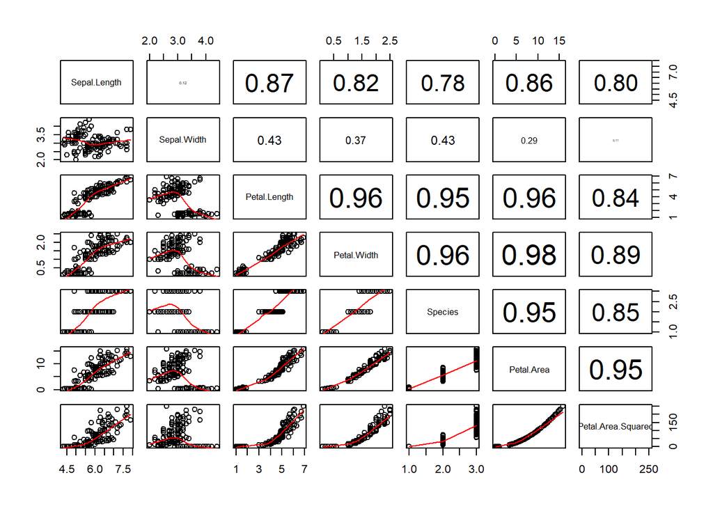

```r
pairs(iris, lower.panel = panel.smooth, upper.panel = panel.cor) # Creates a correlation plot
```

For a slightly fancier version of the same plot you can run the code below (though they show the same thing)

```r
# install.packages("GGally")
library(GGally)
```

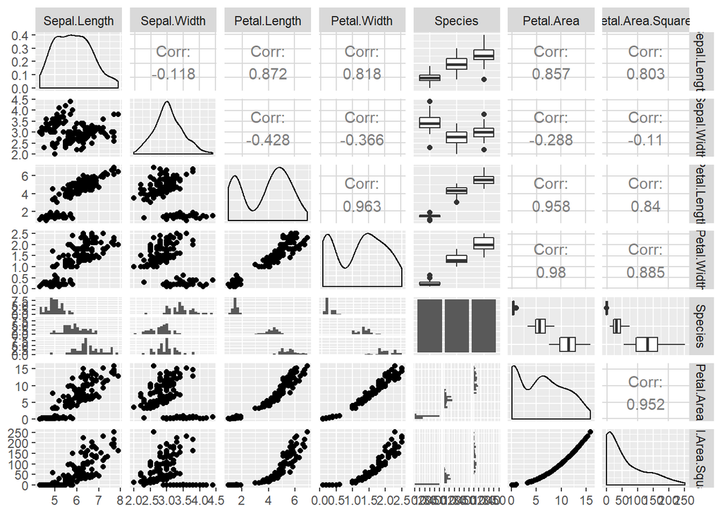

```r
ggpairs(iris)
```

An alternative

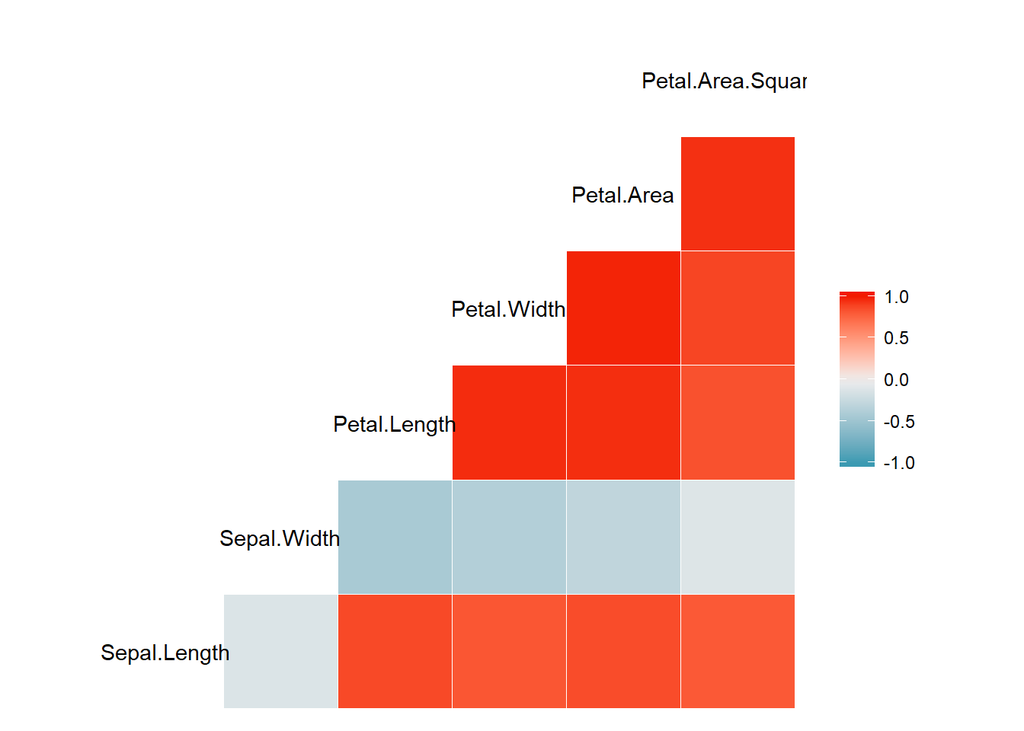

```r
ggcorr(iris, method = c("everything", "pearson"))
```

The iris dataset has lots of collinearity. For the purposes of this Study Group Session, let’s just ignore that they are correlated.  
In practice, you would normally exclude one of the variables (usually the least interesting one) and keep one in the model.

# ———————————————————————————

# STEP 5: Creating a linear model

# ———————————————————————————

```r
Model.1 <- lm(Sepal.Length ~ Species * Petal.Area, data = iris)
```

That’s all the code needed to run a linear model. It’s really not difficult to run a model. Hard part is all the work leading up to the and afterwards.

# ———————————————————————————

# STEP 6: Diagnostic check of the model

# ———————————————————————————

We will dicuss this

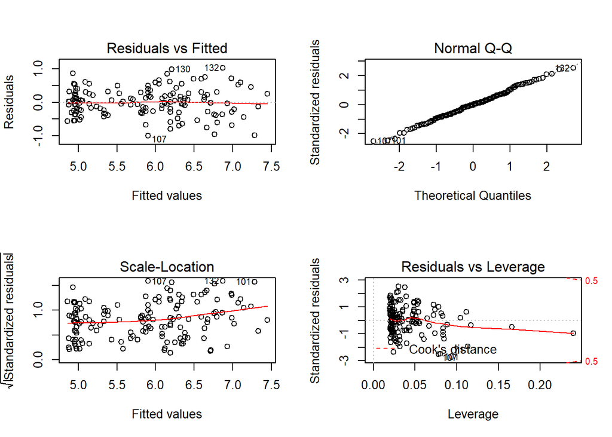

```r
par(mfrow = c(2,2))
plot(Model.1)
```

```r
par(mfrow = c(1,1))
```

# ———————————————————————————

# STEP 7: Model selection

# ———————————————————————————

```r
AIC(Model.1)                                # E.g. returns an AIC = 100
```

```
## [1] 168.9251
```

```r
Model.2 <- lm(Sepal.Length ~ Species + Petal.Area, data = iris)
AIC(Model.2)                                # E.g. returns an AIC = 110
```

```
## [1] 167.7032
```

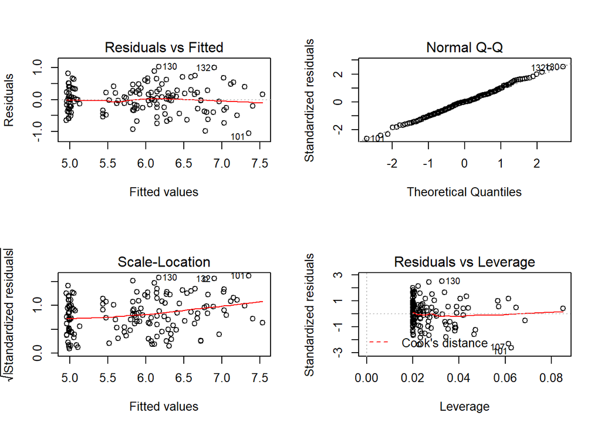

```r
par(mfrow = c(2,2))
plot(Model.2)                               # This will plot the graphs discussed above
```

```r
Model.3 <- lm(Sepal.Length ~ Species, data = iris)
AIC(Model.3)                                # E.g. returns an AIC = 110
```

```
## [1] 231.452
```

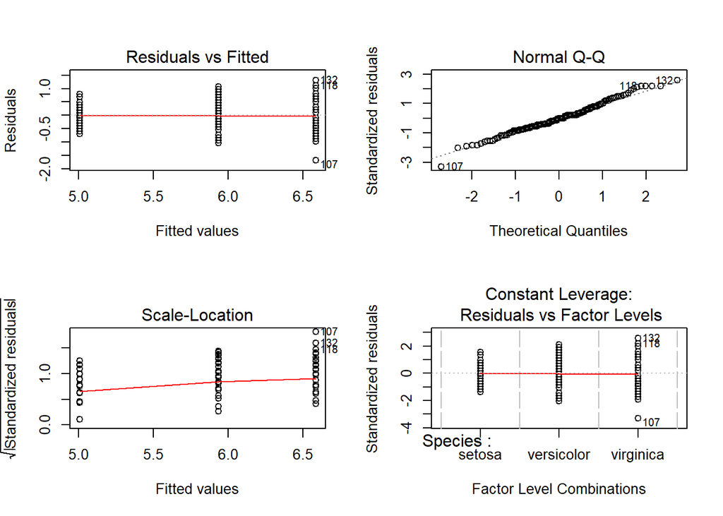

```r
plot(Model.3)                               # This will plot the graphs discussed above
```

```r
Model.4 <- lm(Sepal.Length ~ Petal.Area, data = iris)
AIC(Model.4)                                # E.g. returns an AIC = 90
```

```
## [1] 174.896
```

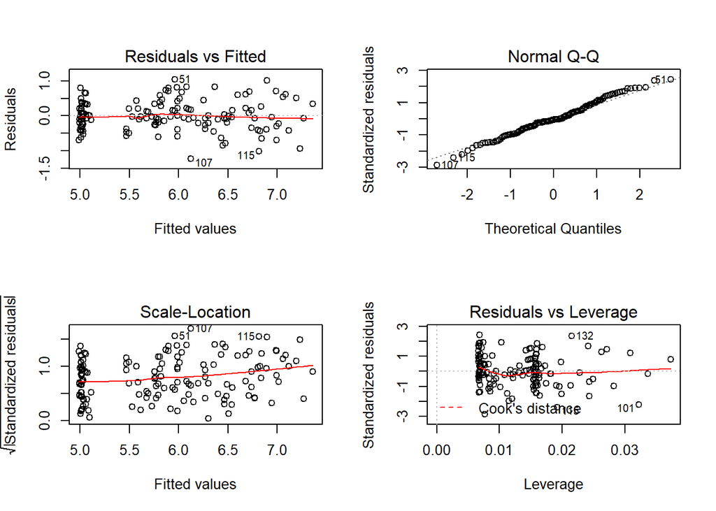

```r
plot(Model.4)                               # This will plot the graphs discussed above
```

```r
par(mfrow = c(1,1))

AIC(Model.1, Model.2, Model.3, Model.4)
```

```
##         df      AIC
## Model.1  7 168.9251
## Model.2  5 167.7032
## Model.3  4 231.4520
## Model.4  3 174.8960
```

In the example AICs, we would choose Model.2 because it has the lowest AIC.

The next best AIC is +1.2219 (the rule is a difference in AIC of >2 allows us to discard a model)

What do we do here then?

- ```
      df      AIC
  ```

- Model.1 7 168.9251 <- Equally good according to AIC
- Model.2 5 167.7032 <- Best according to AIC
- Model.3 4 231.4520
- Model.4 3 174.8960

This means that the model with an interaction term and the model with only additive terms are equivalent.

# ———————————————————————————

# STEP 8: Coefficient table and the important info

# ———————————————————————————

Let’s start by look at our best model (i.e. model 2)

```r
anova(Model.2)
```

```
## Analysis of Variance Table
##
## Response: Sepal.Length
##             Df Sum Sq Mean Sq F value    Pr(>F)
## Species      2 63.212 31.6061 183.615 < 2.2e-16 ***
## Petal.Area   1 13.825 13.8249  80.316 1.388e-15 ***
## Residuals  146 25.131  0.1721
## ---
## Signif. codes:  0 '***' 0.001 '**' 0.01 '*' 0.05 '.' 0.1 ' ' 1
```

Understanding the ANOVA results of a model

Df = degrees of freedom

- Think of this like a currency. The more samples, the more money. To do analysis costs money. The more “things” a bit of analysis has to calculate, the more expensive it is.

Sum Sq = Sums of squares

- Variation explained by each variable and residuals (the numbers themselves mean nothing)

Mean Sq = Sum Sq / Df

- Variation axplained divided by how “expensive” it was to calculate

F value = Mean Sq (of variable) / Mean Sq (of Residuals)

- Ratio of explained variation divided by unexplained variation

P-value based on F value (large F value often = small p-value)

- Depends on Df and an F distribution

Residuals = remaining variation

- Unexplained variation

You can calculate the total variation in the dataset

```r
63.212 + 13.825 + 25.131
```

```
## [1] 102.168
```

Let’s see what proportion of variance we are explaining:

```r
(63.212 + 13.825) / 102.168
```

```
## [1] 0.7540228
```

0.7540228 (we explain about 75% of the total variation with Species and Petal.Area)

- 75% is the R-sq value! (See below in summary(Model.2))

Let’s use Model.2 to start looking at the coefficient table

```r
summary(Model.2)
```

```
##
## Call:
## lm(formula = Sepal.Length ~ Species + Petal.Area, data = iris)
##
## Residuals:
##      Min       1Q   Median       3Q      Max
## -1.05613 -0.28357  0.00553  0.24753  1.03014
##
## Coefficients:
##                   Estimate Std. Error t value Pr(>|t|)
## (Intercept)        4.93018    0.05928  83.166  < 2e-16 ***
## Speciesversicolor -0.18054    0.14913  -1.211   0.2280
## Speciesvirginica  -0.68490    0.26621  -2.573   0.0111 *
## Petal.Area         0.20739    0.02314   8.962 1.39e-15 ***
## ---
## Signif. codes:  0 '***' 0.001 '**' 0.01 '*' 0.05 '.' 0.1 ' ' 1
##
## Residual standard error: 0.4149 on 146 degrees of freedom
## Multiple R-squared:  0.754,  Adjusted R-squared:  0.749
## F-statistic: 149.2 on 3 and 146 DF,  p-value: < 2.2e-16
```

Questions:

- 1. What are residuals?
- 2. Can you draw the results out by hand?
- 3. What do the p-values mean?
- 4. What do the R-sqaured values mean? What are the adjusted vrs multiple R-squared?
- 5. What does the F-statistic p-value mean?

Answers:

- 1. Residuals is all of the variation in the data that your model does not explain, any trend in these suggest that there are variables in your system that you are not taking into accounts. Or that you may not have a linear relationship (or many other things)
- 2. We’ll do this on a board or in paint or something.
- 3. The null hypothesis of these are that each are not different from 0 (both y-intercept and gradient), but also if different levels of, e.g. a factor, are different from each other.
- 4. Multiple r-squared is the correlation coefficient. 0 means no correlation between response and explanatories, 1 means perfect correlation. Adjusted r-squared adjusts the r-squared based on the number of variables in the model.
- 5. The F-statistic p-value tests the hypothesis that your modelled data is no different from a model with completely random data. p < 0.05 means your model is significantly different from a model with random data.

And Model.1 which had our interaction

```r
summary(Model.1)
```

```
##
## Call:
## lm(formula = Sepal.Length ~ Species * Petal.Area, data = iris)
##
## Residuals:
##      Min       1Q   Median       3Q      Max
## -1.00178 -0.27854 -0.00243  0.26470  1.02898
##
## Coefficients:
##                              Estimate Std. Error t value Pr(>|t|)
## (Intercept)                    4.7945     0.1329  36.071   <2e-16 ***
## Speciesversicolor             -0.2805     0.2867  -0.978   0.3296
## Speciesvirginica              -0.3325     0.3420  -0.972   0.3326
## Petal.Area                     0.5785     0.3264   1.772   0.0784 .
## Speciesversicolor:Petal.Area  -0.3300     0.3293  -1.002   0.3179
## Speciesvirginica:Petal.Area   -0.3903     0.3276  -1.192   0.2353
## ---
## Signif. codes:  0 '***' 0.001 '**' 0.01 '*' 0.05 '.' 0.1 ' ' 1
##
## Residual standard error: 0.4139 on 144 degrees of freedom
## Multiple R-squared:  0.7585, Adjusted R-squared:  0.7502
## F-statistic: 90.47 on 5 and 144 DF,  p-value: < 2.2e-16
```

# ———————————————————————————

# STEP 9: Plotting output of the model

# ———————————————————————————

We’ll use the package jtools here to make life easier on ourselves

```r
library(jtools)
```

https://cran.r-project.org/web/packages/jtools/vignettes/summ.html

See the above url for a fantastic vignette (guide) on how to use the package. It has many uses!

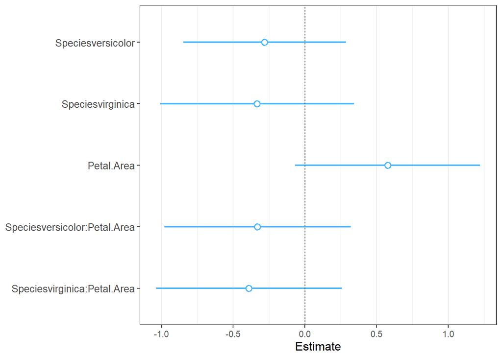

```r
plot_summs(Model.1)
```

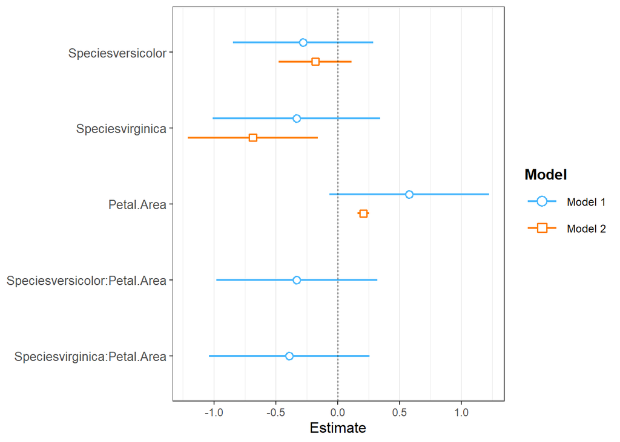

```r
plot_summs(Model.1, Model.2)
```

If you want to get specific predictions from your model to see what is happening with each explanatory variable:

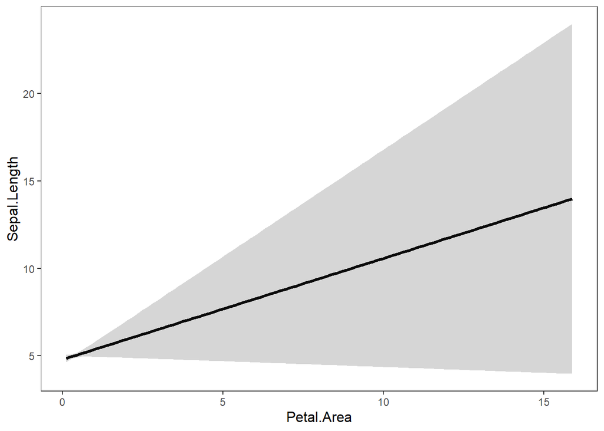

```r
effect_plot(Model.1, pred = Petal.Area, interval = TRUE)
```

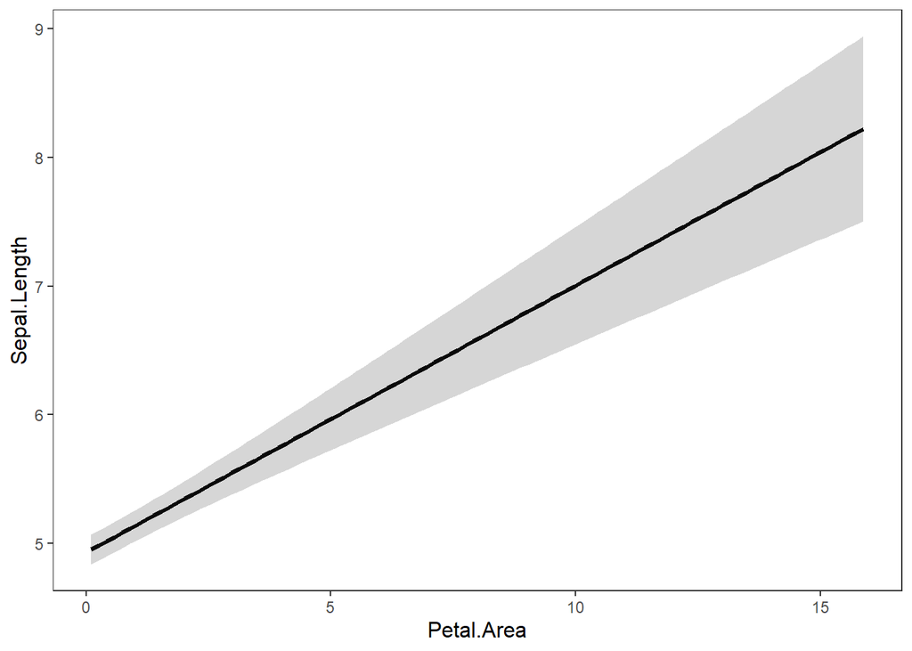

```r
effect_plot(Model.2, pred = Petal.Area, interval = TRUE)
```

To plot the factor variables

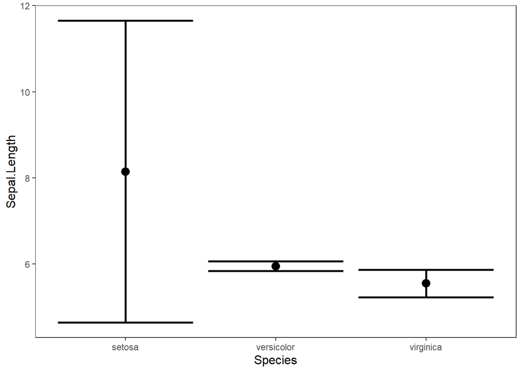

```r
cat_plot(Model.1, pred = Species, interval = T)
```

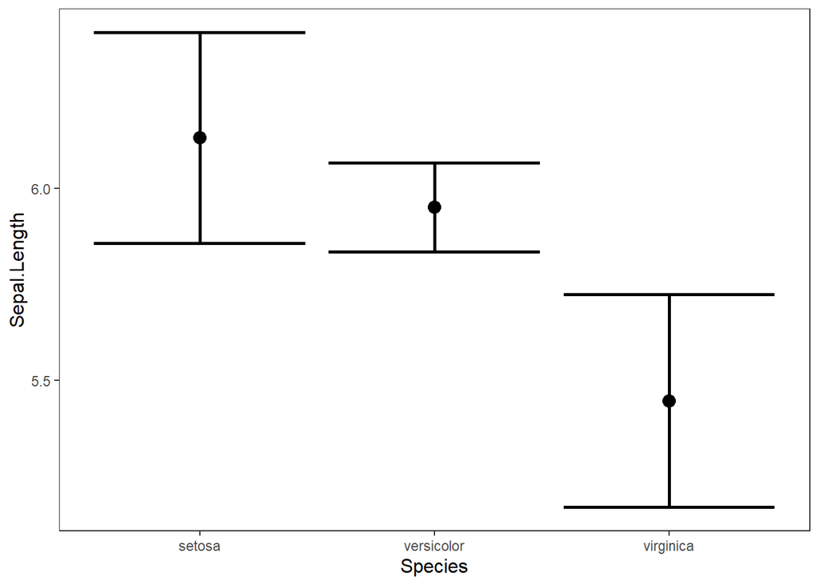

```r
cat_plot(Model.2, pred = Species, interval = T)
```

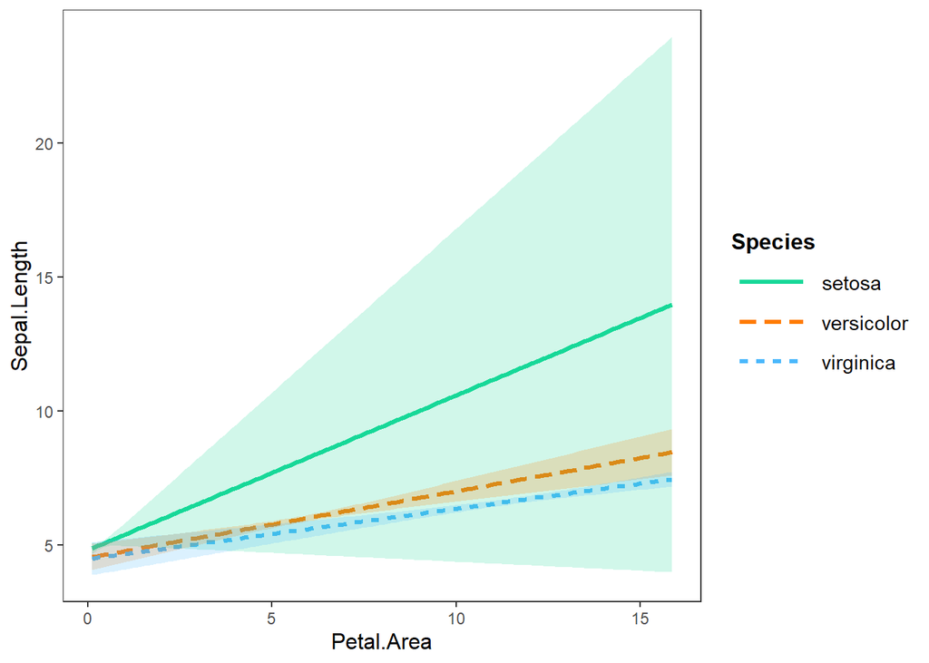

```r
interact_plot(Model.1, pred = Petal.Area, modx = Species, interval = TRUE)
```

Why does the SE envelope get so big for setosa?

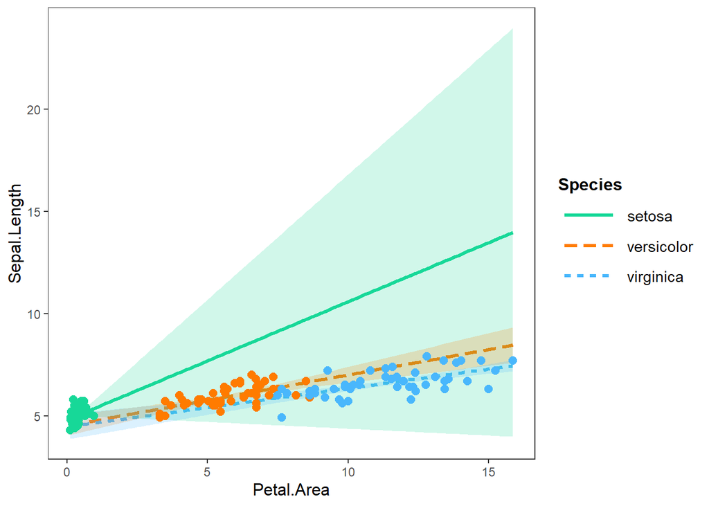

```r
interact_plot(Model.1, pred = Petal.Area, modx = Species, interval = TRUE, plot.points = T)
```

Plot for best model:

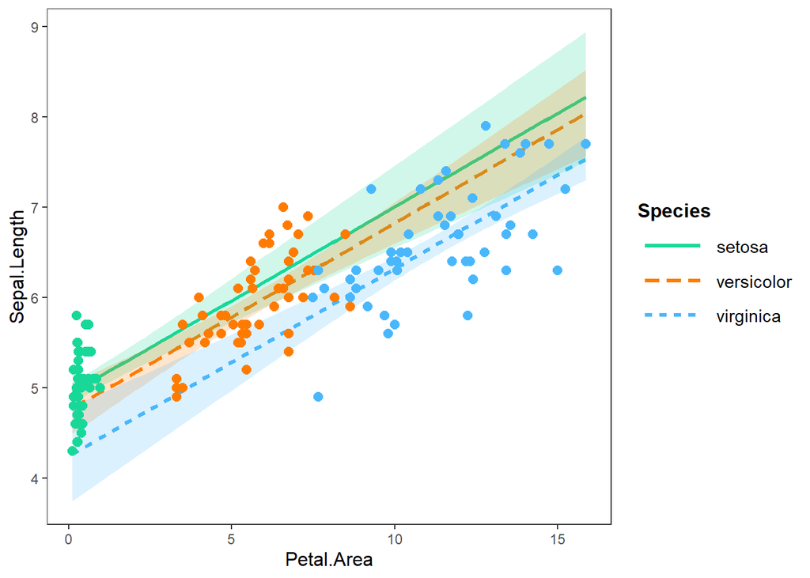

```r
interact_plot(Model.2, pred = Petal.Area, modx = Species, interval = TRUE, plot.points = T)
```

# ———————————————————————————

# STEP 10: Publish and retire on a lovely beach

# ———————————————————————————